# Introduction to TidierPlots.jl

Randall Boyes

## About Me

- Epidemiologist
- Currently: Analytics at Presage Group

## The “tidyverse”

- The best reason to still use R
- Comprehensive, connected set of packages for reading, wrangling, and visualizing data

## Tidier.jl

- 100% Julia reimplementation of R’s tidyverse
  - TidierData.jl - dplyr/tidyr
  - TidierFiles.jl - readr
  - TidierDB.jl - dbplyr
  - TidierString.jl - stringr
  - TidierCats.jl - forcats
  - TidierText.jl - tidytext
  - TidierPlots.jl - ggplot2

## Brief Introduction to ggplot

- “Part of” the tidyverse
- Data visualization
- Based on grammar of graphics

```julia
library(ggplot2)

ggplot(mpg, aes(x = displ, y = hwy, colour = class)) +
  geom_point()
```

[figure not shown]

```julia
library(ggplot2)

ggplot(mpg, aes(x = displ, y = hwy, colour = class)) +
  geom_point() + geom_line()
```

[figure not shown]

```julia
library(ggplot2)

ggplot(mpg, aes(x = displ, y = hwy, colour = class)) +
  geom_point() + theme_classic()
```

[figure not shown]

## Key Ideas

- Build up any plot that you want by “adding” data, aes mapping, options, themes, etc.
- “Defaults” in the `ggplot` function pass down to the `geom_*` objects

## The First Pass

```julia
using Makie, CairoMakie, AlgebraOfGraphics
using PalmerPenguins, DataFrames

penguins = dropmissing(DataFrame(PalmerPenguins.load()))

struct geom
    visual::Union{Symbol, Nothing}
    aes::Dict
    args::Dict
    analysis::Any
    required_aes::AbstractArray
end

struct ggplot
    geoms::AbstractArray
    default_aes::Dict
    data::Symbol
    axis::NamedTuple
end
```

## The First Pass

```julia
function Base.:+(x::ggplot, y...)::ggplot
    result = ggplot(vcat(x.geoms, [i for i in y]),
        x.default_aes,
        x.data,
        x.axis)

    return result
end
```

## The First Pass

```julia
function extract_aes(geom)
    aes_dict = Dict{String, Symbol}()
    args_dict = Dict{String, Any}()

    for section in geom
        if section isa Expr
            # if the section is an expression, check if it is a aes function call
            if section.args[1] == :aes
                for aes_ex in section.args
                    if aes_ex isa Expr
                        aes_dict[String(aes_ex.args[1])] = aes_ex.args[2]
                    end
                end
            # if not, its a generic argument
            else
                args_dict[String(section.args[1])] = section.args[2]
            end
        end
    end

    return (aes_dict, args_dict)
end

function check_aes(required_aes, aes_dict)
    for aes in required_aes
        if !haskey(aes_dict, aes)
            error("missing required aesthetic: $aes")
        end
    end
end
```

## The First Pass

```julia
macro geom_point(exprs...)
    geom_visual = :Scatter
    aes_dict, args_dict = extract_aes(:($(exprs)))
    analysis = nothing
    required_aes = ["x", "y"]
    check_aes(required_aes, aes_dict)
    return geom(geom_visual, aes_dict, args_dict, nothing, required_aes)
end

macro geom_smooth(exprs...)
    geom_visual = nothing
    aes_dict, args_dict = extract_aes(:($(exprs)))
    analysis = AlgebraOfGraphics.smooth
    required_aes = ["x", "y"]
    if haskey(args_dict, "method")
        if args_dict["method"] == "lm"
            analysis = AlgebraOfGraphics.linear
        end
    end
    check_aes(required_aes, aes_dict)
    return geom(geom_visual, aes_dict, args_dict, analysis, required_aes)
end
```

## The First Pass

```julia
function geom_to_layer(geom)
    mapping_args = (geom.aes[key] for key in geom.required_aes)

    layer = data(eval(geom.args["data"])) *
        mapping(mapping_args...)

    if !isnothing(geom.analysis)
        layer = layer * (geom.analysis)()
    end

    if !isnothing(geom.visual)
        layer = layer * visual(eval(geom.visual))
    end

    if haskey(geom.aes, "color")
        layer = layer * mapping(color = geom.aes["color"])
    end

    return layer
end
```

## The First Pass

```julia
function draw_ggplot(plot::ggplot)
    for geom in plot.geoms
        # if data is not specified at the geom level, use the ggplot default
        if !haskey(geom.args, "data")
            geom.args["data"] = plot.data
        end

        # if an aes isn't given in the geom, use the ggplot aes
        for aes in keys(plot.default_aes)
            if !haskey(geom.aes, aes)
                geom.aes[aes] = plot.default_aes[aes]
            end
        end
    end

    layers = []

    for geom in plot.geoms
        push!(layers, geom_to_layer(geom))
    end

    if length(layers) == 0
        error("No geoms supplied")
    elseif length(layers) == 1
        draw(layers[1]; axis = plot.axis)
    else
        draw((+)(layers...); axis = plot.axis)
    end
end
```

## The First Pass

```julia
test_plot = @ggplot(data = penguins, aes(color = species)) +
    @geom_point(aes(x = bill_length_mm, y = bill_depth_mm)) +
    @geom_smooth(aes(x = bill_length_mm, y = bill_depth_mm), method = "lm")

draw_ggplot(test_plot)
```

[figure not shown]

## Enter TidierPlots

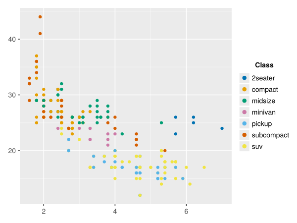

```julia
using TidierPlots

ggplot(mpg, aes(x = :displ, y = :hwy, color = :class)) +
  geom_point()
```

## How does it work?

TidierPlots.jl provides:

- A set of structs corresponding to ggplot concepts (GGPlot, Geom, Aes, etc.)
- Functions that look like ggplot functions that generate those structs
- Definitions for operators using those structs (`+`)
- A way to translate all of this to `Makie.SpecApi`

## What can it do?

```julia
beautiful_makie_theme = Attributes(
    fonts=(;regular="CMU Serif"),
)

ggplot(df) +
    geom_point(
        aes(x = :x, y = :y, size = :size, color = :x),
        alpha = 0.8) +
    scale_x_log10() +
    scale_y_log10() +
    labs(x = "x", y = "y") +
    lims(y = c(.1, 100)) +
    scale_color_continuous(
        palette = "Hiroshige", name = "") +
    theme(
        xminorticksvisible=true,
        xminorgridvisible=true,
        yminorticksvisible=true,
        yminorgridvisible=true,
        xminorticks=IntervalsBetween(9),
        yminorticks=IntervalsBetween(9),
        backgroundcolor = :transparent,
        xgridstyle=:dash,
        ygridstyle=:dash
    ) + beautiful_makie_theme
```

## What can it do?

[figure not shown]

## What can it do?

```julia
Random.seed!(123)
n = 200
df = DataFrame(x = randn(n) / 2, y = randn(n))

top = ggplot(df) +
    geom_histogram(aes(x = :x), color = (:orangered, 0.5), strokewidth = 0.5) +
    lims(x = c(-4, 4)) +
    theme(xticklabelsvisible = false, xgridvisible = false) +
    beautiful_makie_theme

right = ggplot(df) +
    geom_histogram(aes(:y), color = (:dodgerblue, 0.5),
        direction = :x, strokewidth = 0.5) +
    lims(y = c(-3, 3)) +
    theme(yticklabelsvisible = false, ygridvisible = false) +
    beautiful_makie_theme

middle = ggplot(df) + geom_point(aes(:x, :y), size = 10) +
    lims(x = c(-4, 4), y = c(-3, 3)) + labs(x = "x", y = "y") +
    beautiful_makie_theme

blank = ggplot() +
    theme(xticklabelsvisible = false, xgridvisible = false, yticklabelsvisible = false,
        ygridvisible = false, xtickcolor = :transparent, ytickcolor = :transparent,
        bottomspinevisible = false, topspinevisible = false, rightspinevisible = false,
        leftspinevisible = false) + beautiful_makie_theme

top + blank + middle + right +
    plot_layout(ncol = 2, nrow = 2, widths = c(3, 1), heights = c(1, 2))
```

## What can it do?

[figure not shown]

## Flying too close to the sun

- `ggplot` allows calculated columns to be created within an `aes` call
- Implemented the closest syntax to this:

```julia
ggplot(data) + geom_point(aes(x = :x/10))
```

- By defining:

```julia
Base.:/(s1::Symbol, s2::Real) = [s1] => AesTransform(make_div_const_fn(s2))
```

## Benefits of over ggplot

- Access to Makie’s theming/options
- Pluto notebook interactivity
- No more dealing with R’s handling of fonts and plot scaling
- Easily add compatibility with more Makie plots

## Benefits of over ggplot

```julia
geom_raincloud = geom_template(
    "geom_raincloud",
    ["x", "y"],
    :RainClouds)

ggplot(penguins) +
    geom_raincloud(
        aes(x = :species,
            y = :bill_depth_mm,
            color = :species),
        size = 4) +
    scale_y_continuous(
        labels = "{:.1f} cm") +
    labs(title = "Bill Depth by Species",
         x = "Species",
         y = "Bill Depth") +
    theme_minimal()
```

[figure not shown]

## What’s next?

- Fix `aes` operations
- `scale_fill` and `scale_alpha`
- `facet_grid`
- More comprehensive documentation and tutorials

## Thanks to contributors

- Karandeep Singh - Tidier
- Alex Knudson - Documentation
- Connor Robertson - Patchwork, Labels
- Daniel Rizk - Documentation
- Pavel Dimens - Logo Design
- You?